# Data visualization

R for Data Science Book

Alexis Solis Cancino https://www.linkedin.com/in/asolisc/  
2020-11-29

# 1. Introduction

The `ggplot2` package is one of the most versatile frameworks for data visualization. It implements the **grammar of graphics** - a system for describing and building graphs by using *layers*. This package is one of the 8 *core-tidyverse* packages.

# 2. First Steps

We first start by loading the `tidyverse` meta-package:

```
library(tidyverse)
```

Then, we can use the `mpg` tibble, a dataset included in the `ggplot2` package. `mpg` contains observations collected by the US Environmental Protection Agency on 38 models of car.

```
mpg
```

```
# A tibble: 234 x 11
   manufacturer model displ  year   cyl trans drv     cty   hwy fl
   <chr>        <chr> <dbl> <int> <int> <chr> <chr> <int> <int> <chr>
 1 audi         a4      1.8  1999     4 auto~ f        18    29 p
 2 audi         a4      1.8  1999     4 manu~ f        21    29 p
 3 audi         a4      2    2008     4 manu~ f        20    31 p
 4 audi         a4      2    2008     4 auto~ f        21    30 p
 5 audi         a4      2.8  1999     6 auto~ f        16    26 p
 6 audi         a4      2.8  1999     6 manu~ f        18    26 p
 7 audi         a4      3.1  2008     6 auto~ f        18    27 p
 8 audi         a4 q~   1.8  1999     4 manu~ 4        18    26 p
 9 audi         a4 q~   1.8  1999     4 auto~ 4        16    25 p
10 audi         a4 q~   2    2008     4 manu~ 4        20    28 p
# ... with 224 more rows, and 1 more variable: class <chr>
```

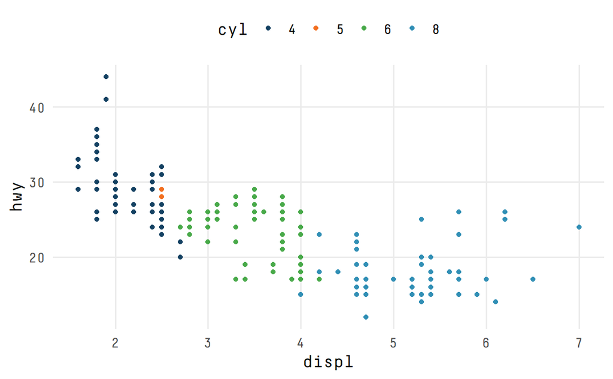

```
mpg %>%
  mutate(cyl = as_factor(cyl)) %>%
  ggplot(mapping = aes(x = displ, y = hwy, colour = cyl)) +
  geom_point() +
  scale_colour_manual(values = amazing_colors)
```

# 3. Aesthetic Mappings

You can add a third variable, like class, to a two dimensional scatterplot by mapping it to an aesthetic. An aesthetic is a visual property of the objects in your plot.

Since we already use the word “value” to describe data, let’s use the word “level” to describe aesthetic properties.

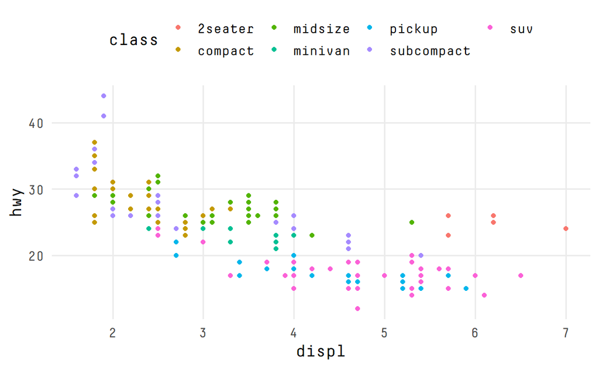

```
mpg %>%
  ggplot() +
  geom_point(mapping = aes(x = displ, y = hwy, color = class))
```

To map an aesthetic to a variable, associate the name of the aesthetic to the name of the variable inside `aes()`. ggplot2 will automatically assign a unique level of the aesthetic (here a unique color) to each unique value of the variable, a process known as scaling.

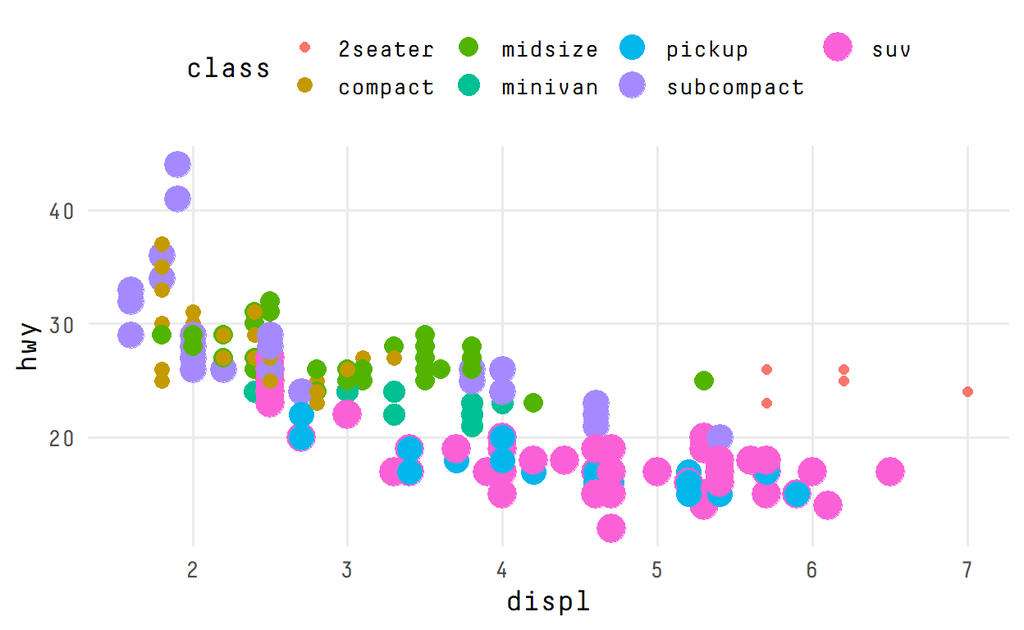

```
mpg %>%
  ggplot() +
  geom_point(mapping = aes(x = displ,
                           y = hwy,
                           size = class,
                           colour = class))
```

We could also use the `alpha` or `shape` aesthetic:

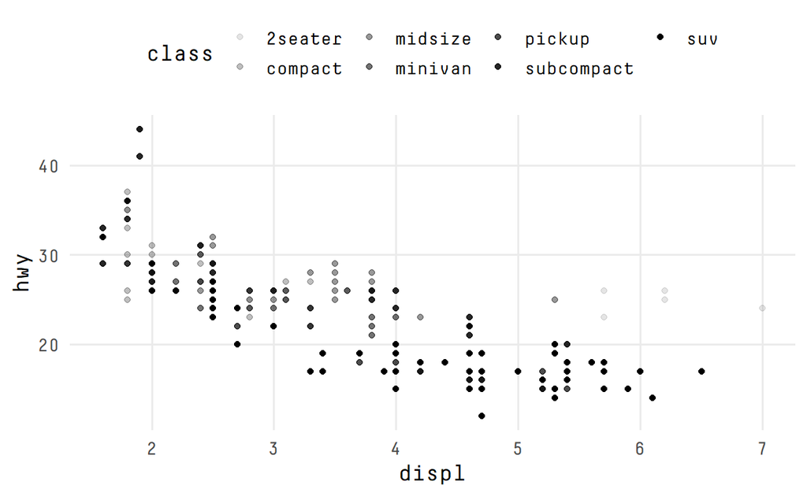

```
mpg %>%
  ggplot() +
  geom_point(aes(x = displ,
                 y = hwy,
                 alpha = class))
```

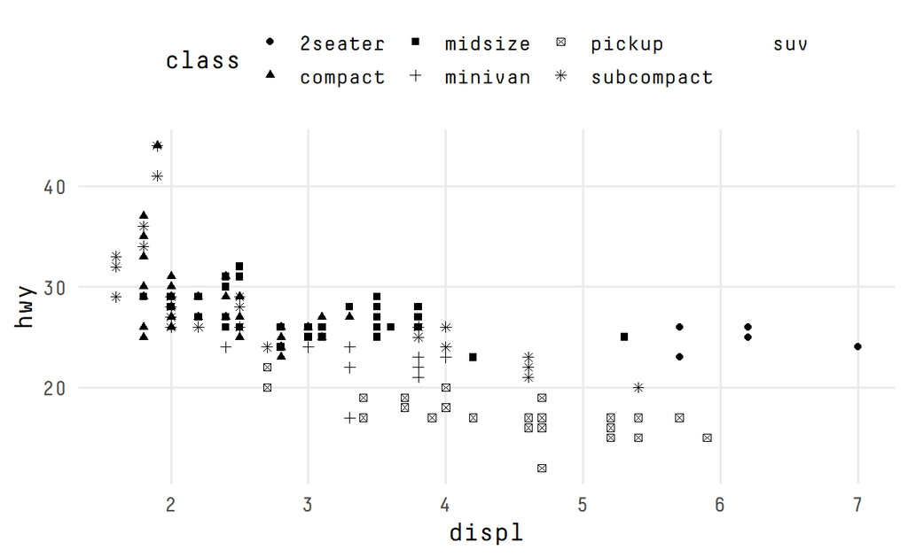

```
mpg %>%
  ggplot(aes(x = displ, y = hwy)) +
  geom_point(aes(shape = class))
```

What happened to the SUVs? ggplot2 will only use six shapes at a time. By default, additional groups will go unplotted when you use the shape aesthetic.

It selects a reasonable scale to use with the aesthetic, and it constructs a legend that explains the mapping between levels and values. For x and y aesthetics, ggplot2 does not create a legend, but it creates an axis line with tick marks and a label. The axis line acts as a legend; it explains the mapping between locations and values.

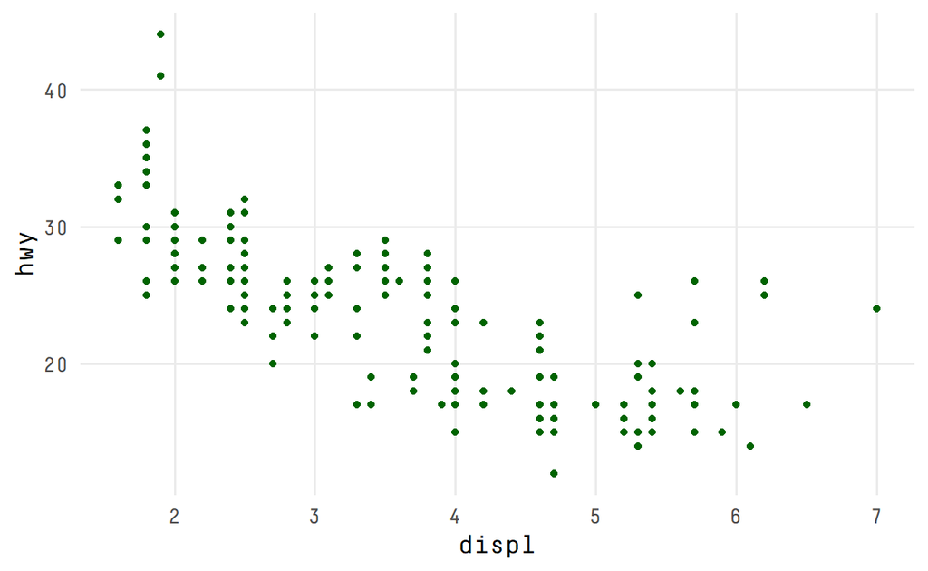

```
mpg %>%
  ggplot() +
  geom_point(mapping = aes(x = displ, y = hwy),
             colour = "dark green")
```

To set an aesthetic manually, set the aesthetic by name as an argument of your geom function; i.e. it goes outside of `aes()`.

## 3.1 Exercises

1. What’s gone wrong with this code? Why are the points not blue?

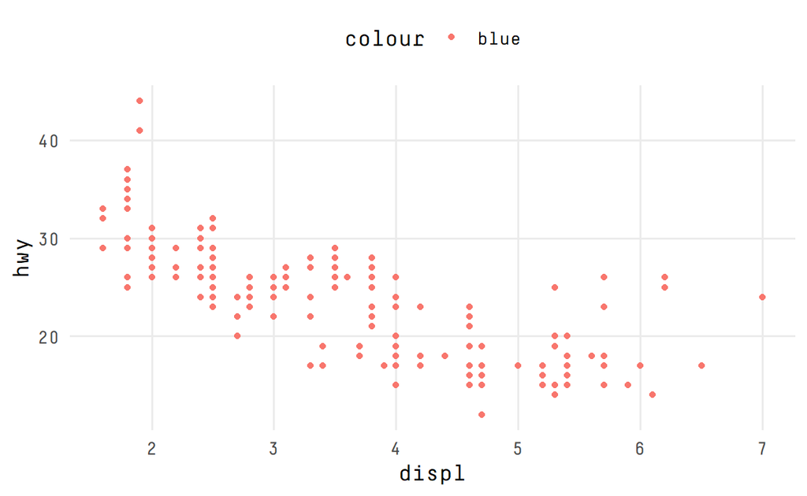

```
mpg %>%
  ggplot() +
  geom_point(mapping = aes(x = displ,
                           y = hwy,
                           color = "blue"))
```

The color should be set outside the `aes()` function, i.e. as an argument to the `geom()` function.

2. Which variables in mpg are categorical? Which variables are continuous? (Hint: type ?mpg to read the documentation for the dataset). How can you see this information when you run `mpg`?

```
# Not run
help(mpg)
```

```
mpg %>% glimpse()
```

```
Rows: 234
Columns: 11
$ manufacturer <chr> "audi", "audi", "audi", "audi", "audi", "aud...
$ model        <chr> "a4", "a4", "a4", "a4", "a4", "a4", "a4", "a...
$ displ        <dbl> 1.8, 1.8, 2.0, 2.0, 2.8, 2.8, 3.1, 1.8, 1.8,...
$ year         <int> 1999, 1999, 2008, 2008, 1999, 1999, 2008, 19...
$ cyl          <int> 4, 4, 4, 4, 6, 6, 6, 4, 4, 4, 4, 6, 6, 6, 6,...
$ trans        <chr> "auto(l5)", "manual(m5)", "manual(m6)", "aut...
$ drv          <chr> "f", "f", "f", "f", "f", "f", "f", "4", "4",...
$ cty          <int> 18, 21, 20, 21, 16, 18, 18, 18, 16, 20, 19, ...
$ hwy          <int> 29, 29, 31, 30, 26, 26, 27, 26, 25, 28, 27, ...
$ fl           <chr> "p", "p", "p", "p", "p", "p", "p", "p", "p",...
$ class        <chr> "compact", "compact", "compact", "compact", ...
```

The categorical variables are:

- `manufacturer`
- `model`
- `trans`
- `drv`
- `fl`
- `class`

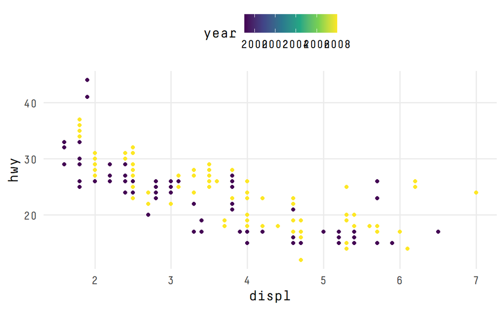

```
mpg %>%
  ggplot() +
  geom_point(aes(x = displ, y = hwy, color = year))
```

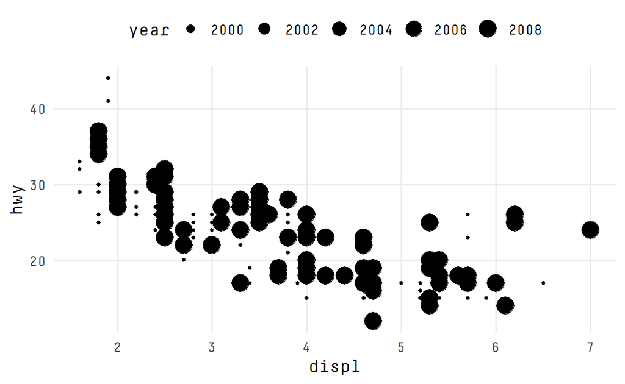

```
mpg %>%
  ggplot() +
  geom_point(aes(x = displ, y = hwy, size = year))
```

```
mpg %>%
  ggplot() +
  geom_point(aes(x = displ, y = hwy, shape = year))
```

The `color`, `shape`, and `size` aesthetics work better with categorical variables. `shape` levels cannot be mapped to a continuous variable.

4. What happens if you map the same variable to multiple aesthetics?

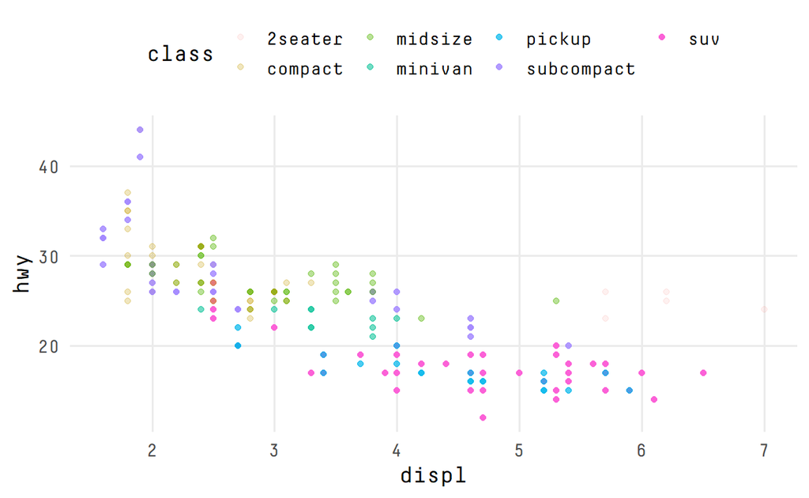

```
mpg %>%
  ggplot() +
  geom_point(aes(x = displ,
                 y = hwy,
                 color = class,
                 alpha = class))
```

`ggplot2` maps them all accordingly.

5. What does the stroke aesthetic do? What shapes does it work with? (Hint: use `?geom_point`).

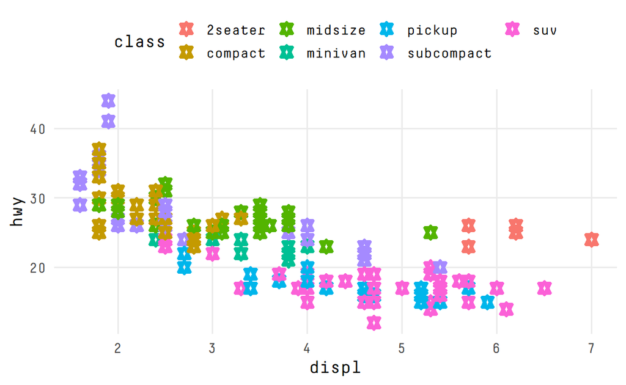

```
mpg %>%
  ggplot() +
  geom_point(aes(x = displ,
                 y = hwy,
                 color = class),
             stroke = 2,
             shape = 11)
```

`stroke` changes the border’s width of certain shapes. For example, shapes 11 and 21 work with stroke. `stroke` is not available for all `geom()` functions.

6. What happens if you map an aesthetic to something other than a variable name, like `aes(colour = displ < 5)`? Note, you’ll also need to specify `x` and `y`.

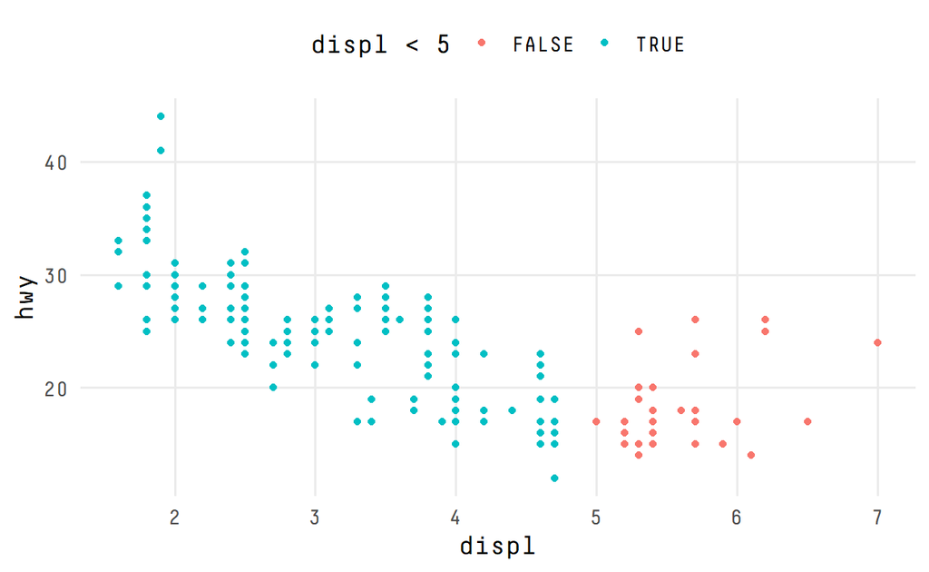

```
mpg %>%
  ggplot() +
  geom_point(mapping = aes(x = displ,
                           y = hwy,
                           colour = displ < 5))
```

## 4. Common Problems

One common problem when creating ggplot2 graphics is to put the `+` in the wrong place: it has to come at the end of the line, not the start. So, for example, the following code is wrong:

```
ggplot(data = mpg)
+ geom_point(mapping = aes(x = displ, y = hwy))
```

## 5. Facets

Another way to add additional variables, particularly useful for categorical variables, is to split your plot into **facets**: subplots that each display one subset of the data.

### Facet by One Variable

To facet your plot by a single variable, use `facet_wrap()`. The first argument of `facet_wrap()` should be a formula created with `~` followed by a variable name. The variable that you pass to `facet_wrap()` *should be discrete*.

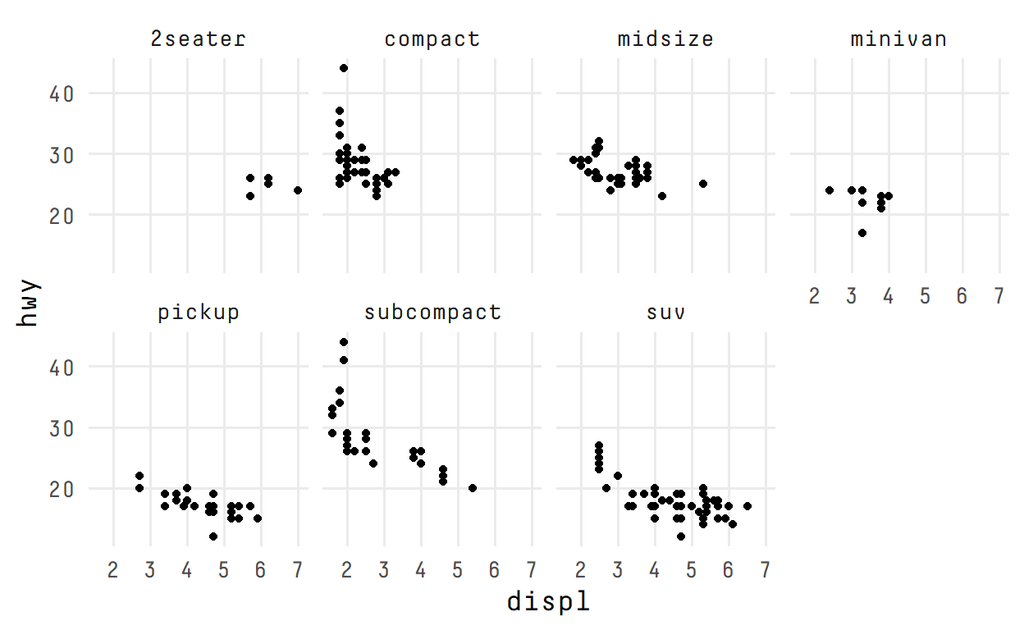

```
mpg %>%
  ggplot() +
  geom_point(mapping = aes(x = displ, y = hwy)) +
  facet_wrap(~ class, nrow = 2)
```

### Facet by Two Variables

To facet your plot on the combination of two variables, add `facet_grid()` to your plot call. The first argument of `facet_grid()` is also a formula. This time the formula should contain two variable names separated by a `~`. For example: `x ~ y`. We can facet the `mpg` dataset by `drv` and `cyl`:

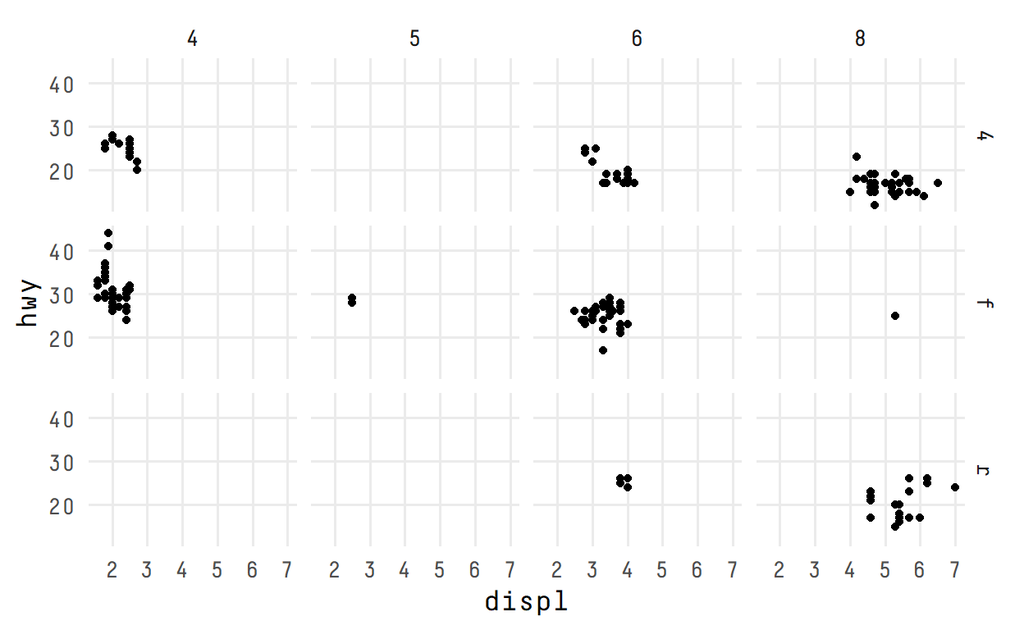

```
mpg %>%
  ggplot() +
  geom_point(mapping = aes(x = displ, y = hwy)) +
  facet_grid(drv ~ cyl)
```

### Facet: Rows Only

If you prefer to not facet in the rows or columns dimension, use a `.` instead of a variable name. Thus, to facet by rows only use: `+ facet_grid(var1 ~ .)`.

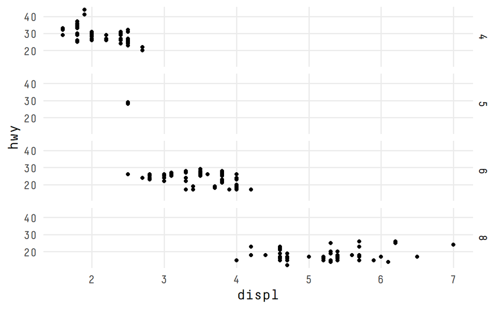

```
mpg %>%
  ggplot() +
  geom_point(mapping = aes(x = displ, y = hwy)) +
  facet_grid(cyl ~ .)
```

### Facet: Columns Only

To facet by columns only use: `+ facet_grid(. ~ var1)`.

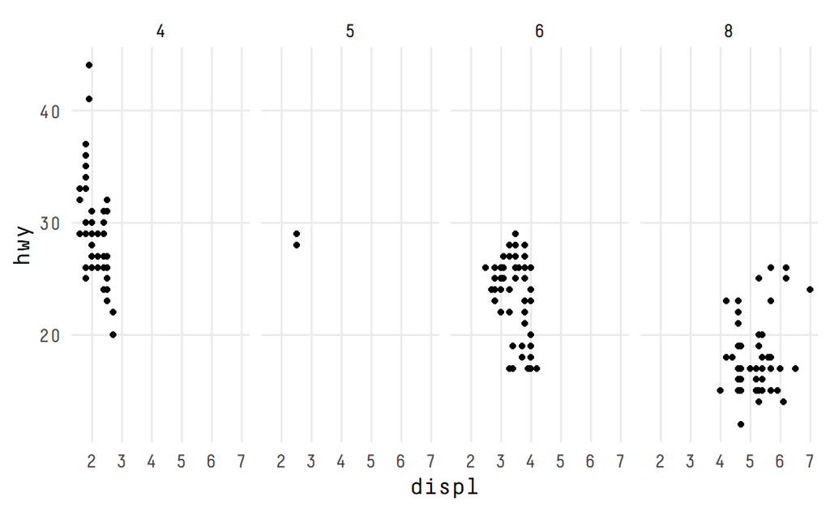

```
mpg %>%
  ggplot() +
  geom_point(mapping = aes(x = displ, y = hwy)) +
  facet_grid(. ~ cyl)
```

## 5.1 Exercises

1. What happens if you facet on a continuous variable?

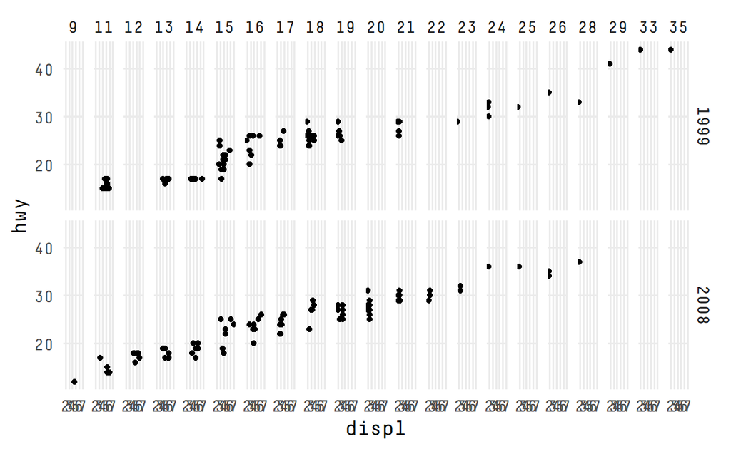

```
mpg %>%
  ggplot(aes(x = displ, y = hwy)) +
  geom_point() +
  facet_grid(year ~ cty)
```

It either displays too many facets or groups them. This happens because the continuous variable is converted to categorical.

2. What do the empty cells in plot with `facet_grid(drv ~ cyl)` mean? How do they relate to this plot?

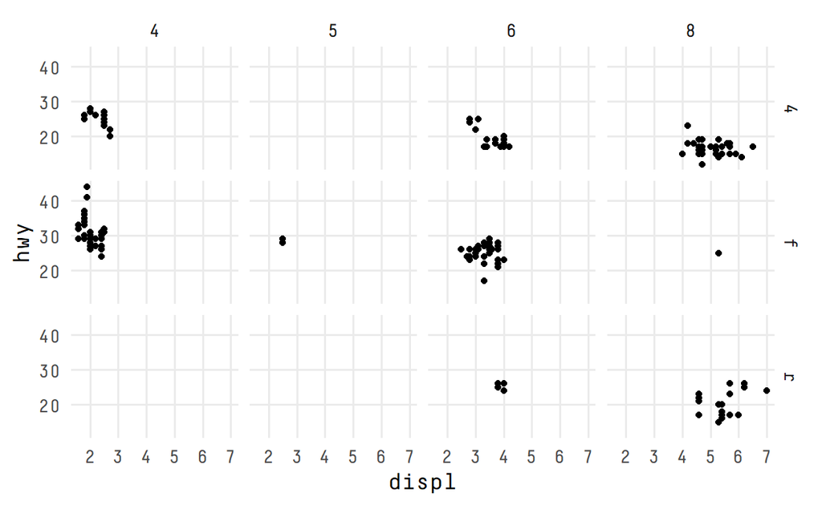

```
mpg %>%
  ggplot(aes(displ, hwy)) +
  geom_point() +
  facet_grid(drv ~ cyl)
```

Empty cells mean that there’s no data that meets the criteria for that specific facet. In this example, it means that there are no 4- and 5-cylinder cars with rear-wheel-drive.

3. What plots does the following code make? What does `.` do?

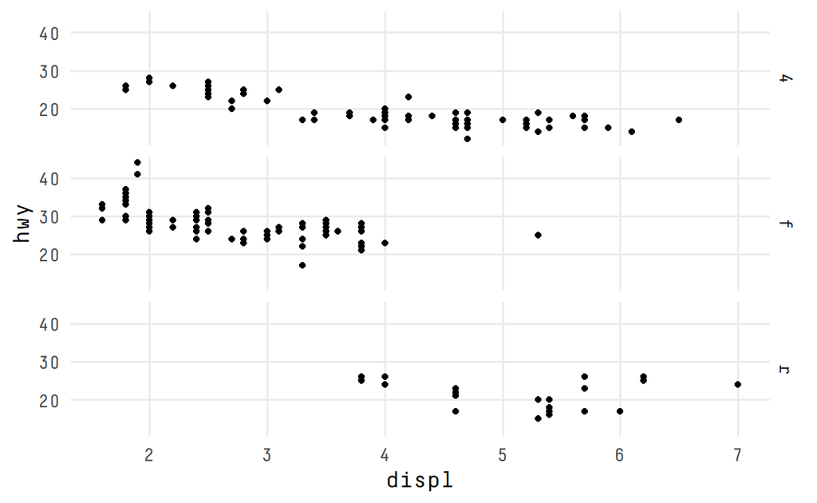

```
ggplot(data = mpg) +
  geom_point(mapping = aes(x = displ, y = hwy)) +
  facet_grid(drv ~ .)
```

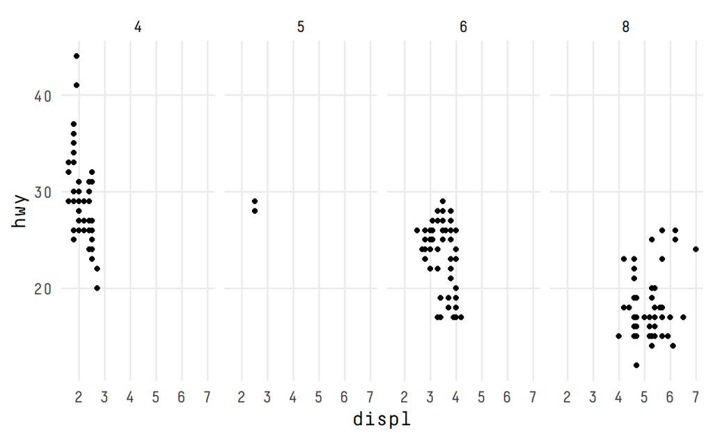

```
ggplot(data = mpg) +
  geom_point(mapping = aes(x = displ, y = hwy)) +
  facet_grid(. ~ cyl)
```

It plots the data into facets according to the variable `drv` and `cyl`, respectively. The `.` argument inside `facet_grid` indicates you’re faceting by only one variable.

4. Take the first faceted plot in this section:

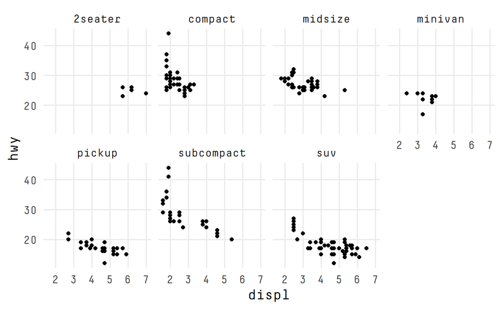

```
ggplot(data = mpg) +
  geom_point(mapping = aes(x = displ, y = hwy)) +
  facet_wrap(~ class, nrow = 2)
```

What are the advantages to using faceting instead of the color aesthetic? What are the disadvantages? How might the balance change if you had a larger dataset?

Faceting actually divides the data into panels, so the separation of the categorical variable is more visual and clear. On the other hand, if the *factor* (categorical) variable had too many different categories, faceting wouldn’t be feasible, since we would have too many panels and it’s no longer practical to visualize. That’s were the `color` aesthetic could work a little bit better.

5. Read `?facet_wrap`. What does `nrow` do? What does `ncol` do? What other options control the layout of the individual panels? Why doesn’t facet_grid() have `nrow` and `ncol` arguments?

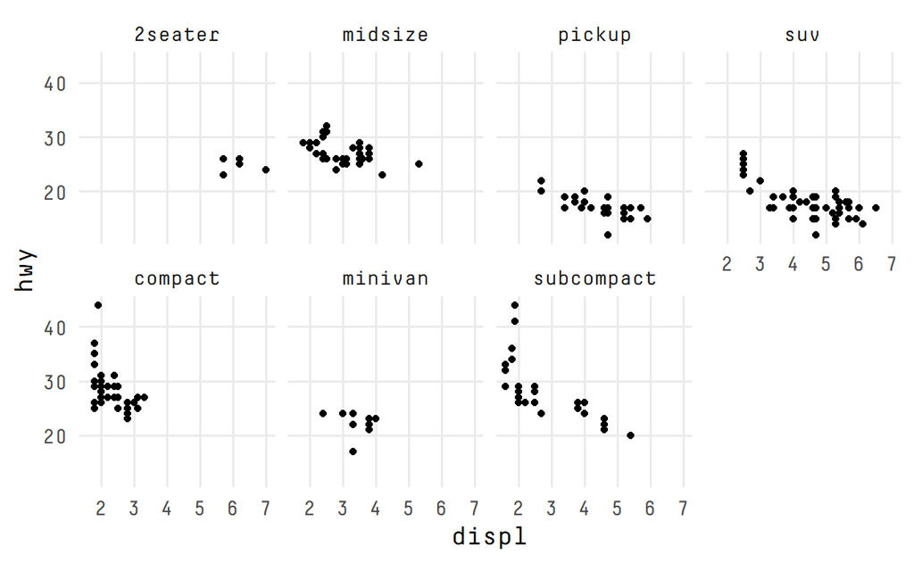

```
ggplot(data = mpg) +
  geom_point(mapping = aes(x = displ, y = hwy)) +
  facet_wrap(~ class, nrow = 2, dir = "v")
```

The `nrow` and `ncol` arguments are unnecessary for `facet_grid()` since the number of unique values of the variables specified in the function determines the number of rows and columns.

6. When using `facet_grid()` you should usually put the variable with more unique levels in the columns. Why?

There will be more space for columns if the plot is laid out horizontally (landscape).

## 6. Geometric Objects

In ggplot2 syntax, there exist different **geoms**. A **geom** is the geometrical object that a plot uses to represent data. To use *geoms* you’ll have to use a family of functions specified by: `geom_*()`.

For example, bar charts use `geom_bar`, line charts use `geom_line()`, boxplots use `geom_boxplot()`, and so on. Scatterplots break the trend, as they are called by using the `geom_point()` *geom*. Below are a couple of examples:

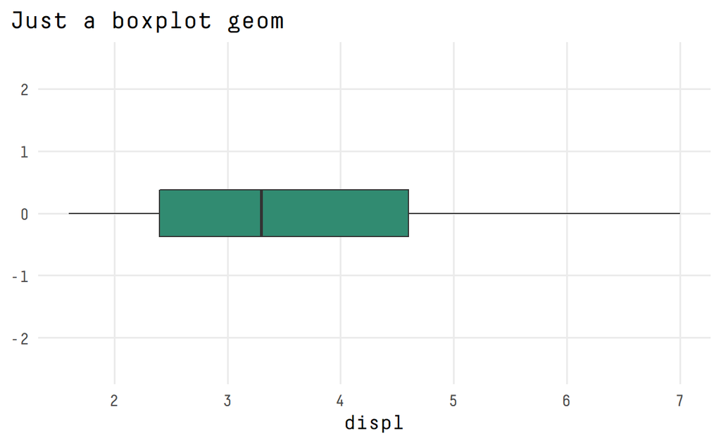

```
mpg %>%
  ggplot(mapping = aes(x = displ)) +
  geom_boxplot(
    fill = amazing_colors[10]) +
  scale_y_continuous(
    limits = c(-2.5,2.5)
  ) +
  labs(
    title = "Just a boxplot geom"
  )
```

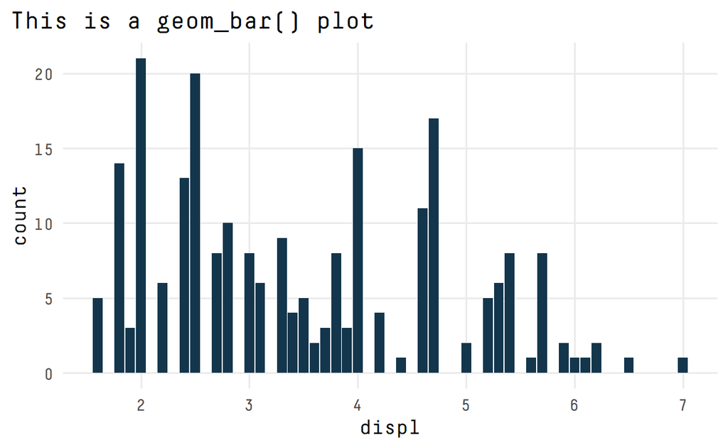

```
mpg %>%
  ggplot(mapping = aes(x = displ)) +
  geom_bar(fill = amazing_colors[8]) +
  labs(
    title = "This is a geom_bar() plot"
  )
```

Every geom function in ggplot2 takes a `mapping` argument. However, not every aesthetic works with every geom. You could set the shape of a point, but you couldn’t set the “shape” of a line. On the other hand, you *could* set the `linetype` of a line. An interesting example is the `geom_smooth()` geom, which will assign a different `linetype` and a different line for each unique value of the variable that you’re mapping to it.

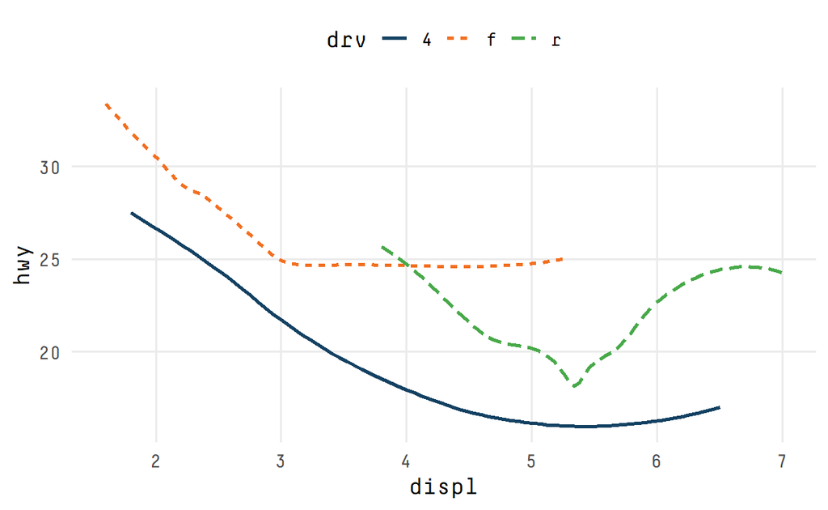

```
mpg %>%
  ggplot() +
  geom_smooth(

    # Map the aesthetics
    mapping = aes(x = displ,
                  y = hwy,
                  linetype = drv,
                  color = drv),

    # Omit the confidence interval
    se = FALSE) +
  scale_color_manual(values = amazing_colors)
```

To better understand what `geom_smooth()` is doing, we can overlay the line on top of the raw data and color everything according to `drv`.

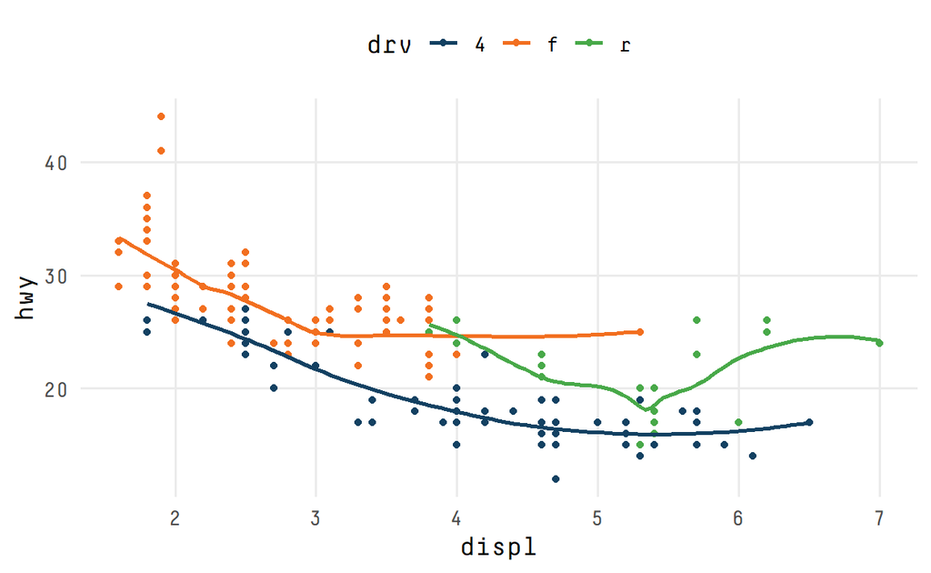

```
mpg %>%

  # Setting "global" aesthetics
  ggplot(aes(x = displ, y = hwy, color = drv)) +

  # scatterplot geom goes first
  geom_point() +

  # geom_smooth goes "on top" of scatterplot
  geom_smooth(se = FALSE) +

  # Choosing the colors manually
  scale_color_manual(values = amazing_colors)
```

### Cheatsheet

`ggplot2` provides over 40 geoms, and [extension packages](https://exts.ggplot2.tidyverse.org/gallery/) provide even more. The best way to get a comprehensive overview is the `ggplot2` cheatsheet.

### The `group` aesthetic

Most *geoms* use a single geometric object (e.g. a line) to display multiple rows of data. If you’d like to display **several objects** to map categorical variables to the geometric objects, you can use the `group` aesthetic.

Actually, `ggplot2` will use the `group` aesthetic when you map categorical variables to any aesthetic, but the convenient feature of `group` is that it doesn’t add a legend or distinguish features to the *geoms*.

For example, see the difference between the following plots:

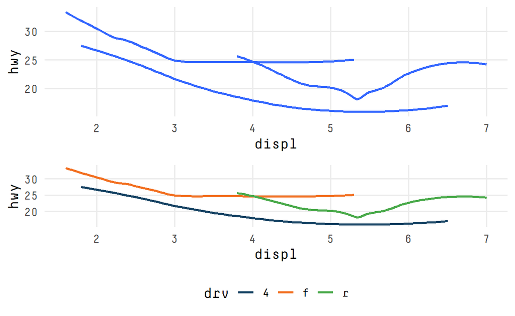

```
library(cowplot)

plot1 <- mpg %>%
  ggplot() +
  geom_smooth(mapping = aes(x = displ, y = hwy, group = drv),
              se = FALSE) +
  scale_color_manual(values = amazing_colors)

plot2 <- mpg %>%
  ggplot() +
  geom_smooth(mapping = aes(x = displ, y = hwy, colour = drv),
              se = FALSE) +
  theme(legend.position = "bottom") +
  scale_color_manual(values = amazing_colors)

cowplot::plot_grid(plot1, plot2, nrow = 2)
```

### Legend display with `show.legend`

If we’d like to delete the legend for the second plot, we can actually add `show.legend = FALSE`:

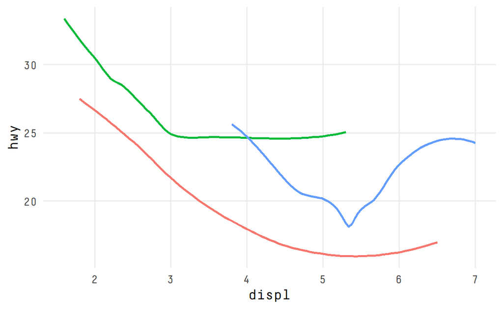

```
mpg %>%
  ggplot() +
  geom_smooth(mapping = aes(x = displ, y = hwy, colour = drv),
              se = FALSE,
              show.legend = FALSE)
```

### Multiple geoms

To add multiple *geoms* in the same plot, simply add multiple `geom_*()` functions to `ggplot()`:

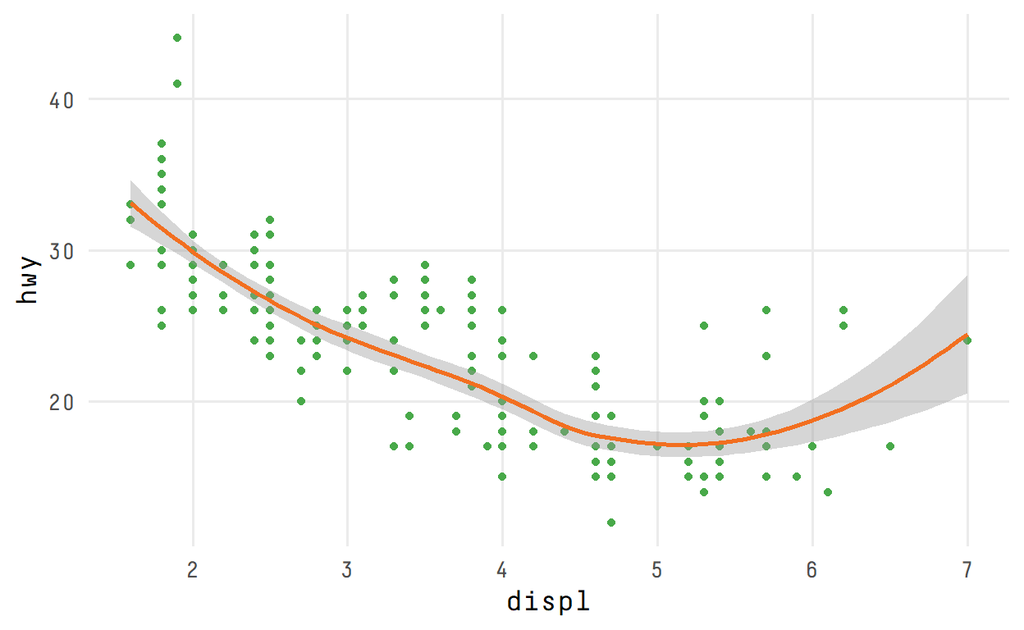

```
mpg %>%
  ggplot() +
  geom_point(mapping = aes(x = displ, y = hwy),
             colour = amazing_colors[3]) +
  geom_smooth(mapping = aes(x = displ, y = hwy),
              colour = amazing_colors[2])
```

### Setting *global* mappings

The code above involved some repetition on the variable mapping. If you wanted to change the mapping, say, of the *y-axis variable*, then it you’d have to change it in both `geom_*()` functions. To avoid this, you can set a global mapping by setting the `mapping = aes()` function inside the `ggplot()` call:

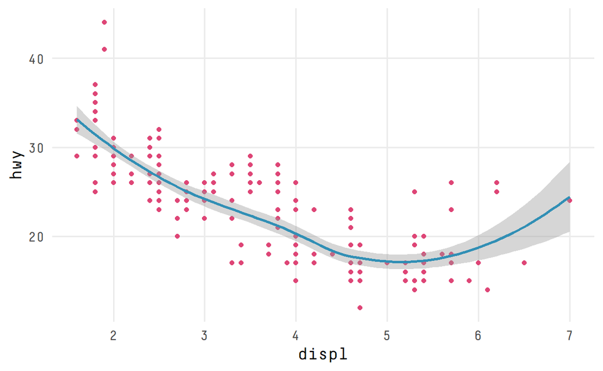

```
mpg %>%
  ggplot(mapping = aes(x = displ, y = hwy)) +
  geom_point(colour = amazing_colors[5]) +
  geom_smooth(colour = amazing_colors[4])
```

### Local mappings

Placing a mapping inside a `geom_*()` function will treat it as a local mapping for that layer. It will overwrite the global mappings set *for that layer only*. This makes it possible to display different aesthetics in different layers:

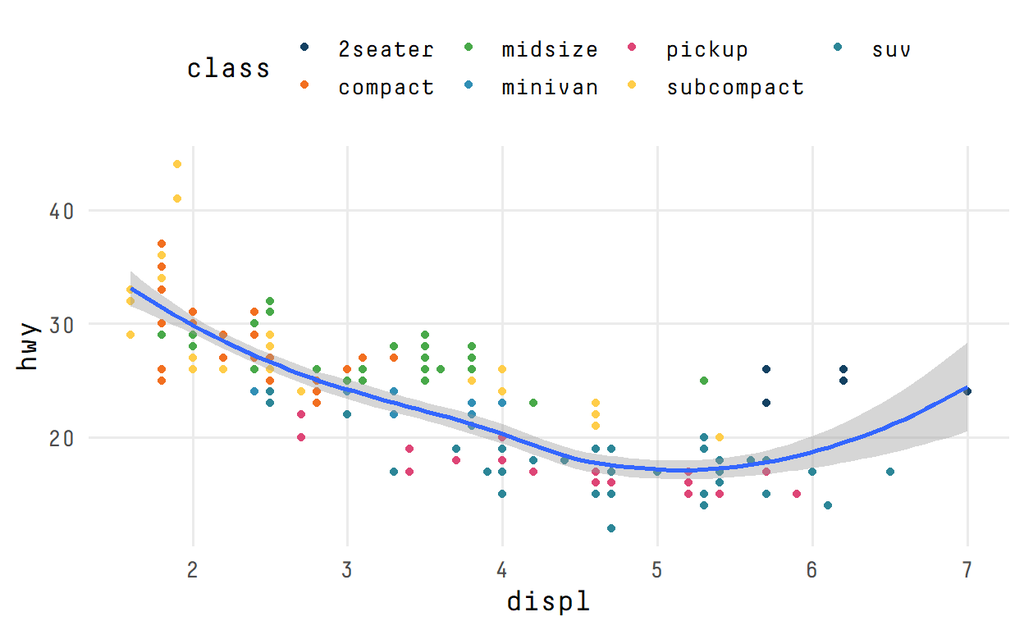

```
mpg %>%
  ggplot(mapping = aes(x = displ, y = hwy)) +
  geom_point(mapping = aes(colour = class)) +
  geom_smooth() +
  scale_colour_manual(values = amazing_colors)
```

### Local Data

You can use the same idea to display *different data on each geom or layer.* In the example below, the smooth line display just a subset of the `mpg` dataset. The *local* `data` argument in `geom_smooth()` overrides the global data argument in `ggplot()` for that layer only:

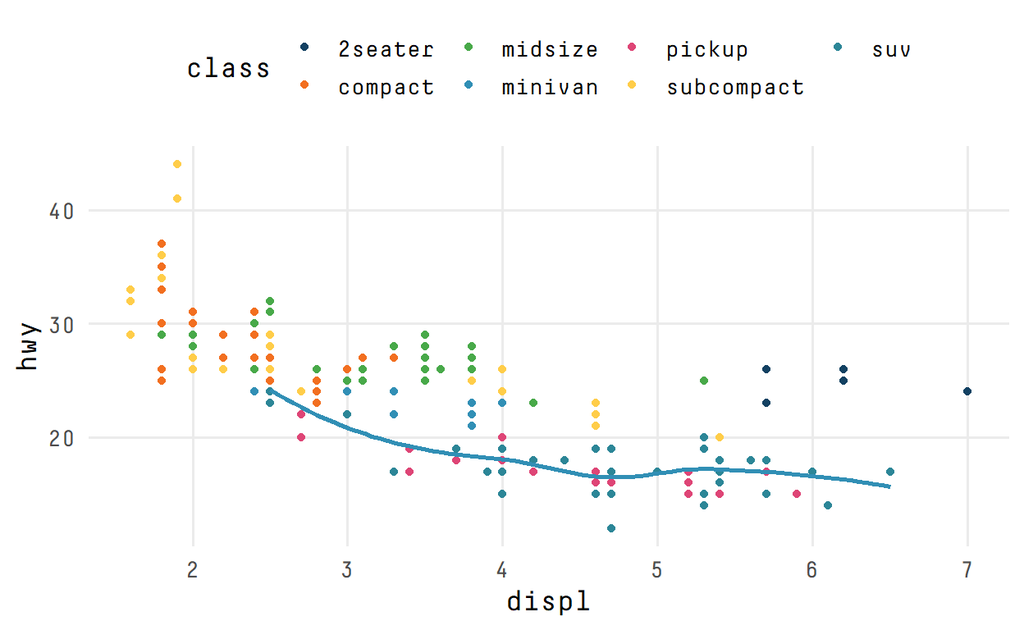

```
ggplot(data = mpg, mapping = aes(x = displ, y = hwy)) +
  geom_point(mapping = aes(colour = class)) +
  geom_smooth(

    # Filter the data for "suv" class
    data = mpg %>% filter(class == "suv"),

    se   = FALSE,
    color = amazing_colors[4]
  ) +
  scale_colour_manual(values = amazing_colors)
```